# Written responses - analysis of coding

George Kinnear

08/10/2021

## Coding

These entries do not use one of the agreed codes for `nature_of_mistake`:

| coder | script | part | nature_of_mistake |
| --- | --- | --- | --- |

These entries do not use one of the agreed codes for `example_type`:

| coder | script | part | example_type |
| --- | --- | --- | --- |

We coded 333 scripts. These were divided between coders, with some overlap.

| coder | n |
| --- | --- |
| BD | 125 |
| GK | 153 |
| PI | 125 |

### Reliability

A total of 42 scripts were coded by more than one coder.

For each of the variables of interest, we construct a table which has a column for each coder’s input for that variable. We then use the `irrCAC` package to compute various reliability measures:

| variable | coeff.name | coeff.val | conf.int |
| --- | --- | --- | --- |
| correct | AC1 | 0.9480200 | (0.911,0.985) |
| correct | Krippendorff’s Alpha | 0.8965000 | (0.827,0.966) |
| correct | Percent agreement | 0.9662698 |  |
| gives_equation | AC1 | 0.9255900 | (0.873,0.978) |
| gives_equation | Krippendorff’s Alpha | 0.9238000 | (0.871,0.976) |
| gives_equation | Percent agreement | 0.9603175 |  |
| example_type | AC1 | 0.8697300 | (0.821,0.919) |
| example_type | Krippendorff’s Alpha | 0.8566700 | (0.806,0.908) |
| example_type | Percent agreement | 0.8809524 |  |
| nature_of_mistake | AC1 | 0.5144100 | (0.345,0.684) |
| nature_of_mistake | Krippendorff’s Alpha | 0.4922800 | (0.337,0.647) |
| nature_of_mistake | Percent agreement | 0.5526316 |  |

#### Disagreements

| script | part | GK__correct | PI__correct | BD__correct |
| --- | --- | --- | --- | --- |
| 119 | b | N | Y |  |
| 212 | a | Y | N | N |
| 212 | b | Y | N | N |
| 218 | c | N | Y | N |
| 219 | b | Y | Y | N |
| 230 | b | Y | Y | N |
| 230 | c | N | Y | N |
| 236 | a | N | Y | Y |

| script | part | GK__gives_equation | PI__gives_equation | BD__gives_equation |
| --- | --- | --- | --- | --- |
| 124 | a | N | Y |  |
| 124 | b | N | Y |  |
| 124 | c | Y | N |  |
| 124 | d | Y | N |  |
| 224 | c | N | Y | N |
| 224 | d | N | Y | N |
| 232 | d | N | N | Y |
| 236 | a | N | N | Y |

| script | part | GK__example_type | PI__example_type | BD__example_type |
| --- | --- | --- | --- | --- |
| 115 | d | piecewise other | piecewise linear |  |
| 118 | a | other - unclear | linear |  |
| 118 | b | other - unclear | cubic |  |
| 118 | c | other - unclear | cubic |  |
| 118 | d | other - unclear | piecewise linear |  |
| 120 | d | other - unclear | piecewise linear |  |
| 123 | c | other - unclear | cubic |  |
| 124 | a | no answer visible | linear |  |
| 124 | b | no answer visible | piecewise linear |  |
| 124 | c | quadratic | piecewise linear |  |
| 212 | d | linear | piecewise linear | linear |
| 216 | d | other - unclear | piecewise linear | other - unclear |
| 217 | d | piecewise linear | other - unclear | piecewise linear |
| 218 | a | not a function | no answer visible | no answer visible |
| 218 | b | trig | other - unclear | trig |
| 218 | c | trig | other - unclear | trig |
| 220 | d | piecewise other | piecewise other | other - unclear |
| 222 | d | other - unclear | piecewise linear | other - unclear |
| 224 | d | other - unclear | piecewise linear | other - unclear |
| 226 | d | other - unclear | piecewise other | other - unclear |
| 228 | d | linear | piecewise linear | linear |
| 233 | b | other - quartic | cubic | other - quartic |
| 233 | c | other - quartic | cubic | other - quartic |
| 236 | b | piecewise linear | linear | piecewise linear |
| 236 | d | linear | no answer visible | linear |

#### Summary of the disagreements

example_type:

| GK__example_type | PI__example_type | BD__example_type | n | scripts |
| --- | --- | --- | --- | --- |
| other - unclear | cubic |  | 3 | 118b, 118c, 123c |
| other - unclear | piecewise linear | other - unclear | 3 | 216d, 222d, 224d |
| linear | piecewise linear | linear | 2 | 212d, 228d |
| other - quartic | cubic | other - quartic | 2 | 233b, 233c |
| other - unclear | piecewise linear |  | 2 | 118d, 120d |
| trig | other - unclear | trig | 2 | 218b, 218c |
| linear | no answer visible | linear | 1 | 236d |
| no answer visible | linear |  | 1 | 124a |
| no answer visible | piecewise linear |  | 1 | 124b |
| not a function | no answer visible | no answer visible | 1 | 218a |
| other - unclear | linear |  | 1 | 118a |
| other - unclear | piecewise other | other - unclear | 1 | 226d |
| piecewise linear | linear | piecewise linear | 1 | 236b |
| piecewise linear | other - unclear | piecewise linear | 1 | 217d |
| piecewise other | piecewise linear |  | 1 | 115d |
| piecewise other | piecewise other | other - unclear | 1 | 220d |
| quadratic | piecewise linear |  | 1 | 124c |

nature_of_mistake:

| GK__nature_of_mistake | PI__nature_of_mistake | BD__nature_of_mistake | n | scripts |
| --- | --- | --- | --- | --- |
| axis not labelled | image goes beyond [0,1] |  | 3 | 122c, 122d, 123c |
| domain has gaps | surjective but should not be | domain has gaps | 2 | 217d, 231d |
| image goes beyond [0,1] | domain has gaps | image goes beyond [0,1] | 2 | 218b, 234b |
| axis not labelled | surjective but should not be |  | 1 | 123d |
| domain exceeds [0,1] | image goes beyond [0,1] |  | 1 | 112c |
| domain exceeds [0,1] | not a function | domain exceeds [0,1] | 1 | 236c |
| domain has gaps | image too small | domain is [0,1/2] | 1 | 236b |
| domain is [0,1/2] | image is [0,1/2] | domain is [0,1/2] | 1 | 224a |
| image goes beyond [0,1] | domain has gaps |  | 1 | 118c |
| image is [0,1/2] | image too small | image is [0,1/2] | 1 | 234c |
| image is [1/2,1] | image is [1/2,1] | domain has gaps | 1 | 230a |
| image too large but still a subset of [0,1] | domain exceeds [0,1] |  | 1 | 118a |
| image too large but still a subset of [0,1] | image goes beyond [0,1] |  | 1 | 118b |
| image too small |  | domain has gaps | 1 | 230c |
| not a function | no answer visible | no answer visible | 1 | 218a |
| surjective but should not be | no answer visible | domain exceeds [0,1] | 1 | 236d |

## Resolving disagreements

The final agreed codings are saved in the following:

- scripts 1-125: GK
- scripts 126-208: PI
- scripts 209-333: BD

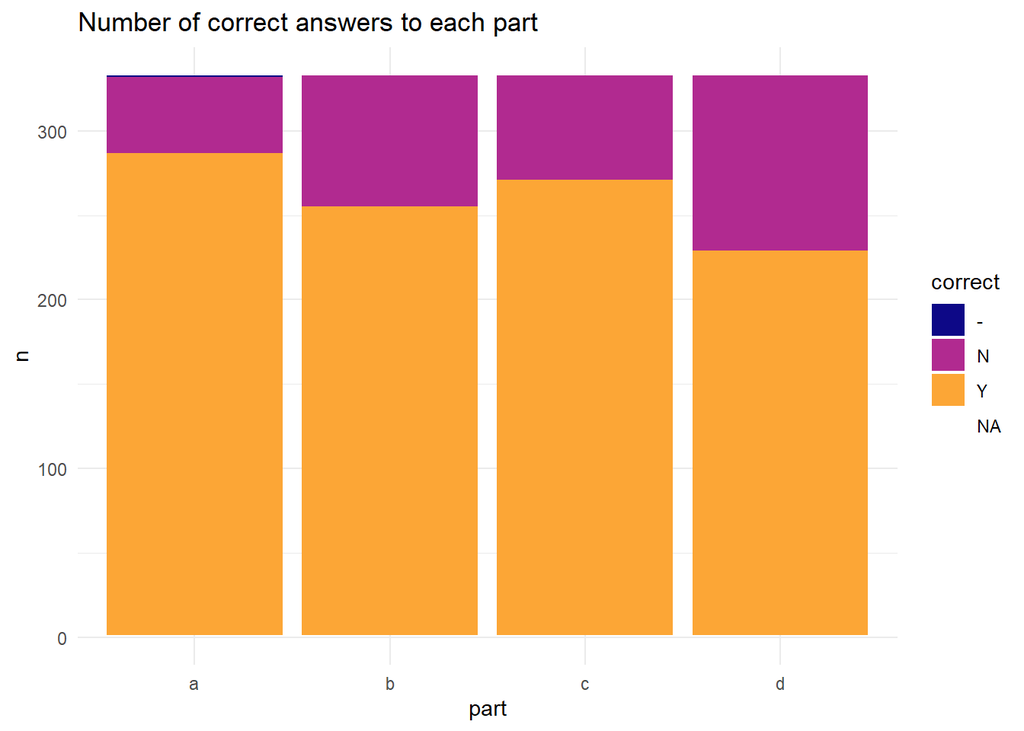

| part | Correct | Incorrect | Total |
| --- | --- | --- | --- |
| a | 286 (86%) | 47 (14%) | 333 (100%) |
| b | 254 (76%) | 79 (24%) | 333 (100%) |
| c | 270 (81%) | 63 (19%) | 333 (100%) |
| d | 228 (68%) | 105 (32%) | 333 (100%) |

part

correct

nature_of_mistake

n

a

Y

285

a

Y

domain is [0,1/2]

1

a

N

surjective but should not be

12

a

N

domain is [0,1/2]

6

a

N

no answer visible

6

a

N

image is [1/2,1]

4

a

N

domain is [0,1/2]; surjective but should not be

3

a

N

image too large but still a subset of [0,1]

3

a

N

domain exceeds [0,1]

2

a

N

image is [0,1/2]

2

a

N

domain has gaps

1

a

N

domain has gaps; image too small

1

a

N

image too small

1

a

N

not a function

1

a

N

surjective but should not be; domain exceeds [0,1]

1

a

N

surjective but should not be; not a function

1

a

N

1

a

no answer visible

1

a

1

b

Y

253

b

Y

image too small

1

b

N

image too small

18

b

N

image too large but still a subset of [0,1]

17

b

N

domain has gaps

7

b

N

not a function

6

b

N

domain is [0,1/2]

5

b

N

image goes beyond [0,1]

4

b

N

no answer visible

4

b

N

image is [1/2,1]

3

b

N

3

b

N

domain exceeds [0,1]; image goes beyond [0,1]

2

b

N

injective but should not be

2

b

N

surjective but should not be

2

b

N

domain exceeds [0,1];

1

b

N

domain exceeds [0,1]; image too large but still a subset of [0,1]

1

b

N

domain is [0,1/2]; surjective but should not be

1

b

N

image is [1/2,1]; domain has gaps

1

b

N

surjective but should not be; not a function

1

b

no answer visible

1

c

Y

269

c

Y

image is [0,1/2]

1

c

N

image too small

11

c

N

image is [0,1/2]

10

c

N

not a function

10

c

N

image goes beyond [0,1]

9

c

N

domain has gaps

5

c

N

domain exceeds [0,1]; image goes beyond [0,1]

3

c

N

no answer visible

3

c

N

axis not labelled

2

c

N

domain exceeds [0,1]

2

c

N

image is [1/2,1]

1

c

N

image too large but still a subset of [0,1]

1

c

N

image too large but still a subset of [0,1]; injective but should not be

1

c

N

image too small; domain has gaps

1

c

N

injective but should not be

1

c

N

undefined at a point

1

c

N

1

c

no answer visible

1

d

Y

227

d

Y

axis not labelled

1

d

N

domain has gaps

38

d

N

surjective but should not be

24

d

N

not injective

11

d

N

no answer visible

6

d

N

axis not labelled

3

d

N

does not pass through the required points

3

d

N

image goes beyond [0,1]

3

d

N

not a function

3

d

N

undefined at a point

3

d

N

image goes beyond [0,1]; undefined at a point

2

d

N

undefined at a point; image goes beyond [0,1]

2

d

N

domain exceeds [0,1]

1

d

N

domain exceeds [0,1]; image goes beyond [0,1]

1

d

N

domain has gaps; not injective

1

d

N

domain is [0,1/2]

1

d

N

surjective but should not be; not injective

1

d

N

1

d

no answer visible

1

## Types of example

| example_type | BD | GK | PI | Total |
| --- | --- | --- | --- | --- |
| cubic | 24 | 31 | 44 | 99 |
| linear | 124 | 150 | 124 | 398 |
| no answer visible | 12 | 6 | 6 | 24 |
| not a function | 0 | 7 | 0 | 7 |
| other - 1/x | 3 | 1 | 0 | 4 |
| other - abs(x) | 3 | 0 | 0 | 3 |
| other - e^x | 1 | 0 | 0 | 1 |
| other - exponential | 0 | 2 | 1 | 3 |
| other - hyperbola | 1 | 0 | 0 | 1 |
| other - ln(x) | 2 | 1 | 0 | 3 |
| other - quartic | 2 | 2 | 0 | 4 |
| other - surd | 1 | 0 | 0 | 1 |
| other - trig (with abs) | 1 | 0 | 0 | 1 |
| other - unclear | 32 | 72 | 21 | 125 |
| piecewise linear | 140 | 149 | 149 | 438 |
| piecewise other | 9 | 13 | 9 | 31 |
| quadratic | 126 | 159 | 129 | 414 |
| trig | 19 | 19 | 13 | 51 |
|  | 0 | 0 | 4 | 4 |
| Total | 500 | 612 | 500 | 1612 |

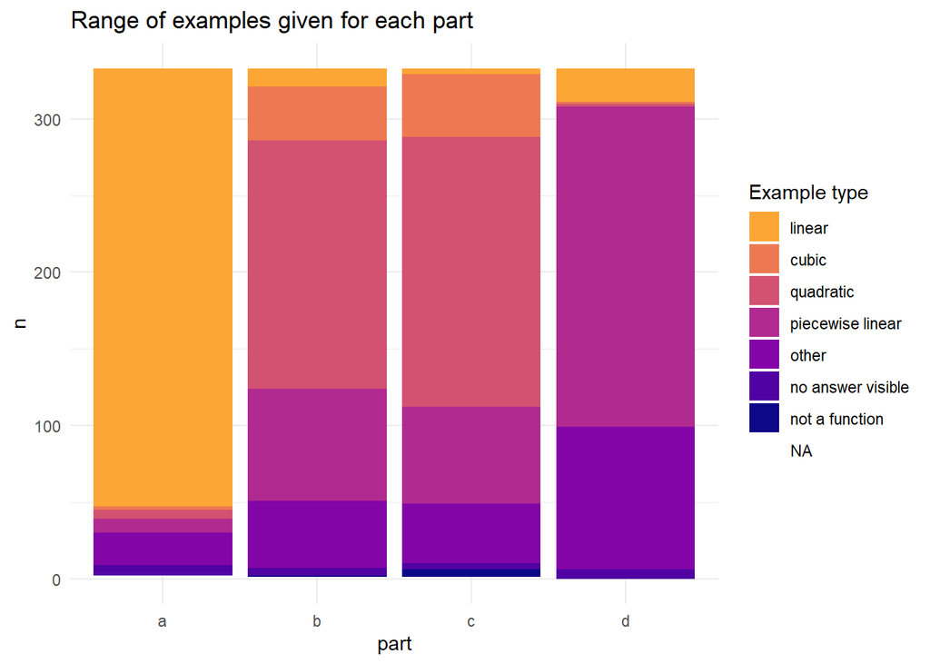

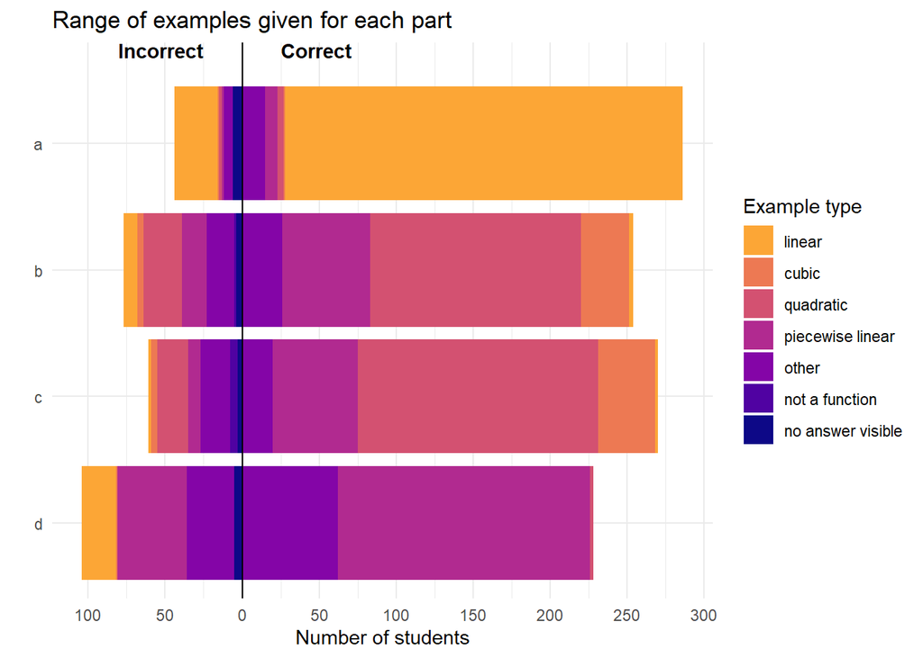

| example_type | a | b | c | d | Total |
| --- | --- | --- | --- | --- | --- |
| cubic | 1 (0%) | 31 (12%) | 37 (14%) | 0 (0%) | 69 (7%) |
| linear | 258 (90%) | 3 (1%) | 2 (1%) | 0 (0%) | 263 (25%) |
| other | 15 (5%) | 26 (10%) | 20 (7%) | 62 (27%) | 123 (12%) |
| piecewise linear | 8 (3%) | 57 (22%) | 55 (20%) | 164 (72%) | 284 (27%) |
| quadratic | 4 (1%) | 137 (54%) | 156 (58%) | 2 (1%) | 299 (29%) |
| Total | 286 (100%) | 254 (100%) | 270 (100%) | 228 (100%) | 1038 (100%) |

# Analysis of each part

## Part (a)

### Incorrect

nature_of_mistake

n

percent

valid_percent

surjective but should not be

12

26.7%

27.3%

domain is [0,1/2]

6

13.3%

13.6%

no answer visible

6

13.3%

13.6%

image is [1/2,1]

4

8.9%

9.1%

domain is [0,1/2]; surjective but should not be

3

6.7%

6.8%

image too large but still a subset of [0,1]

3

6.7%

6.8%

domain exceeds [0,1]

2

4.4%

4.5%

image is [0,1/2]

2

4.4%

4.5%

domain has gaps

1

2.2%

2.3%

domain has gaps; image too small

1

2.2%

2.3%

image too small

1

2.2%

2.3%

not a function

1

2.2%

2.3%

surjective but should not be; domain exceeds [0,1]

1

2.2%

2.3%

surjective but should not be; not a function

1

2.2%

2.3%

1

2.2%

Total

45

| coder | script | nature_of_mistake |
| --- | --- | --- |
| GK | 2 | domain is [0,1/2]; surjective but should not be |
| GK | 11 | surjective but should not be |
| GK | 16 | surjective but should not be |
| GK | 44 | domain is [0,1/2]; surjective but should not be |
| GK | 69 | domain is [0,1/2]; surjective but should not be |
| PI | 146 | surjective but should not be |
| PI | 161 | surjective but should not be; not a function |
| PI | 162 | surjective but should not be |
| PI | 177 | surjective but should not be |
| PI | 179 | surjective but should not be |

[output cut: 7 more lines]

| coder | script | nature_of_mistake |
| --- | --- | --- |
| PI | 161 | surjective but should not be; not a function |
| BD | 255 | not a function |

## Part (b)

### Incorrect

nature_of_mistake

n

percent

valid_percent

image too small

18

23.1%

24.0%

image too large but still a subset of [0,1]

17

21.8%

22.7%

domain has gaps

7

9.0%

9.3%

not a function

6

7.7%

8.0%

domain is [0,1/2]

5

6.4%

6.7%

image goes beyond [0,1]

4

5.1%

5.3%

no answer visible

4

5.1%

5.3%

image is [1/2,1]

3

3.8%

4.0%

3

3.8%

domain exceeds [0,1]; image goes beyond [0,1]

2

2.6%

2.7%

injective but should not be

2

2.6%

2.7%

surjective but should not be

2

2.6%

2.7%

domain exceeds [0,1];

1

1.3%

1.3%

domain exceeds [0,1]; image too large but still a subset of [0,1]

1

1.3%

1.3%

domain is [0,1/2]; surjective but should not be

1

1.3%

1.3%

image is [1/2,1]; domain has gaps

1

1.3%

1.3%

surjective but should not be; not a function

1

1.3%

1.3%

Total

78

| coder | script | nature_of_mistake |
| --- | --- | --- |
| BD | 259 | domain exceeds [0,1]; image goes beyond [0,1] |
| BD | 288 | domain exceeds [0,1]; image goes beyond [0,1] |
| BD | 298 | domain exceeds [0,1]; image too large but still a subset of [0,1] |
| GK | 93 | image goes beyond [0,1] |
| BD | 218 | image goes beyond [0,1] |
| BD | 234 | image goes beyond [0,1] |
| BD | 243 | image goes beyond [0,1] |
| PI | 200 | image is [1/2,1] |
| PI | 208 | image is [1/2,1] |
| BD | 315 | image is [1/2,1] |

[output cut: 36 more lines]

| coder | script | nature_of_mistake |
| --- | --- | --- |
| GK | 50 | domain is [0,1/2]; surjective but should not be |
| PI | 161 | surjective but should not be; not a function |
| PI | 179 | surjective but should not be |
| PI | 181 | surjective but should not be |

For students who made a mistake with the image in (b), what did they do in (a)?

| coder | script | correct | nature_of_mistake |
| --- | --- | --- | --- |
| GK | 11 | N | surjective but should not be |
| GK | 16 | N | surjective but should not be |
| GK | 44 | N | domain is [0,1/2]; surjective but should not be |
| GK | 69 | N | domain is [0,1/2]; surjective but should not be |
| GK | 118 | N | image too large but still a subset of [0,1] |
| PI | 161 | N | surjective but should not be; not a function |
| PI | 179 | N | surjective but should not be |
| PI | 181 | N | surjective but should not be |
| BD | 212 | N | surjective but should not be |
| BD | 218 | N | no answer visible |

[output cut: 18 more lines]

| coder | script | nature_of_mistake |
| --- | --- | --- |
| BD | 270 | domain exceeds [0,1]; |
| GK | 30 | domain has gaps |
| GK | 58 | domain has gaps |
| PI | 144 | domain has gaps |
| PI | 164 | domain has gaps |
| BD | 214 | domain has gaps |
| BD | 219 | domain has gaps |
| BD | 230 | domain has gaps |
| GK | 63 | domain is [0,1/2] |
| GK | 107 | domain is [0,1/2] |

[output cut: 19 more lines]